# A3: Incarceration

5-20-24

### Summary Information

Looking at the data collected by the Vera institute it was clear that it would be important to analyze variables surrounding incarceration by race. First off looking at one of the most affected by incarceration, the black population prison rate, it can be seen that the highest rate of incarceration for black people was 24,818 in the US in 1998. Comparing this to the white population prison rate, they had a high of only 9,945 in the same year of 1998. Comparing these two data points alone speak volumes as to how incarceration has one sidedly been effecting the black population unfairly. But what about other races? When looking at the AAPI prison population rate it can be seen that the highest was at 2031 in 2015. Furthermore when looking at the higher population rate for the latino prison population, it can be seen in 2008 having a high 25,074. When comparing this to the rest of the data it can be seen that it is not only black people that are being wrongly effected by incarceration but also Latinx as well having the highest incarceration rate out of all the data values so far. When looking at the highest average incarceration population rate in total across the US in 2009 at 478, it’s astonishing to see the difference between the highest average incarceration rate overall and the different values of incarceration rates broken down by race revealing the unnatural fluctuations in incarceration for certain races.

### The Dataset

Who collected the data?

The Vera Institute

How was the data collected or generated?

The Vera Institute collected data through documents and datasets published through the Washington Department of Justice

Why was the data collected?

The data was collected to bring awareness about the unjust and unfairness of modern incarceration and how the data from it can be used to come up with solutions to reduce incarceration

How many observations (rows) are in your data?

1131

How many features (columns) are in the data?

23

What, if any, ethical questions or questions of power do you need to consider when working with this data?

Some questions of power to consider when working with this data include considering the specific people that may have collected and curated this data. The people who collected this data tend to be the ones that are in power and non minorities. Therefore it is important to consider how even if there are good intentions for this data, there can still be consequential implications depending on how it is presented and perceived.

What are possible limitations or problems with this data? (at least 200 words)

Some limitations to this data include the fact that this data may not include those who were not incarcerated for a long enough period of time. It’s also important to consider that those who died in prison due to unknown reasons may be left out of the data as well and therefore leading to less statistics on incarceration. Furthermore the data does not give any information on what crime was committed. Knowing what these incarcerated individuals were accused for or any context for the case or reason they were incarcerated would make the data even more helpful. Also it is important to know any health conditions or financial situations that might have motivated people at the time to do certain actions that led to incarceration. These are all extremely important data points that can shed more light on trends around incarceration and as how to stop it. Not to mention legal systems and law can be very complicated and clearly has a huge effect on incarceration rates. Knowing what policies were changing or being implemented at the time of certain trends or spikes in incarceration rates in general or for specific races would enhance the data further. Another limit of the data is not knowing any social movements or political movements that might have been going on at the time that influenced incarceration rates of certain races.

### Trends Over Time Chart

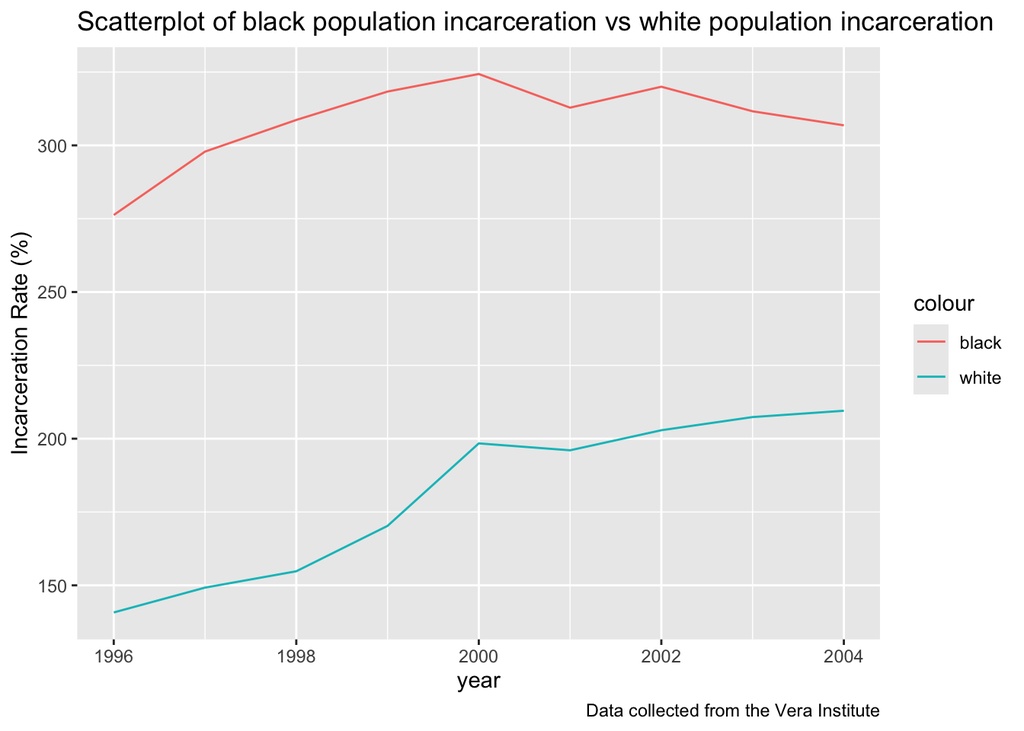

### Reasoning and Patterns

This chart showing the black prison population over time across the US over time is important to show the incarceration by race. Specifically I chose this graph to show the extreme difference in incarceration rates between the white population and black population over time to reveal any trends during certain years that may have effected the incarcerations between the two. Some noticeable trends was that both incarceration rates for the black and white population steadily increased from 1996 to 2000. Furthermore there was slight decrease in incarceration rates for both populations around 2001 and then closer to 2004 there was an decrease in incarcertaion rate for the black population and an increase for the white population.

### Variable Comparison Chart

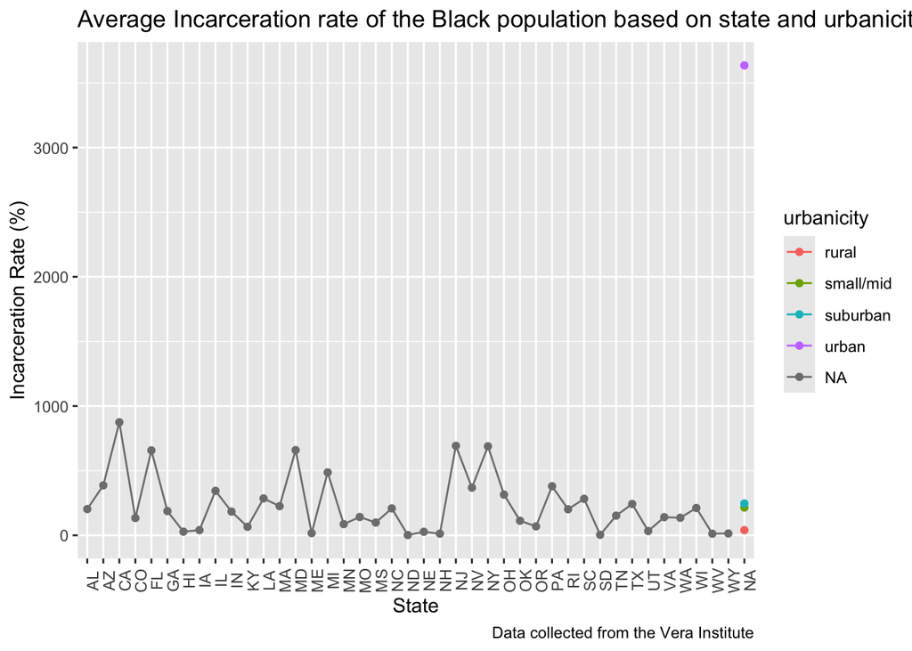

### Map

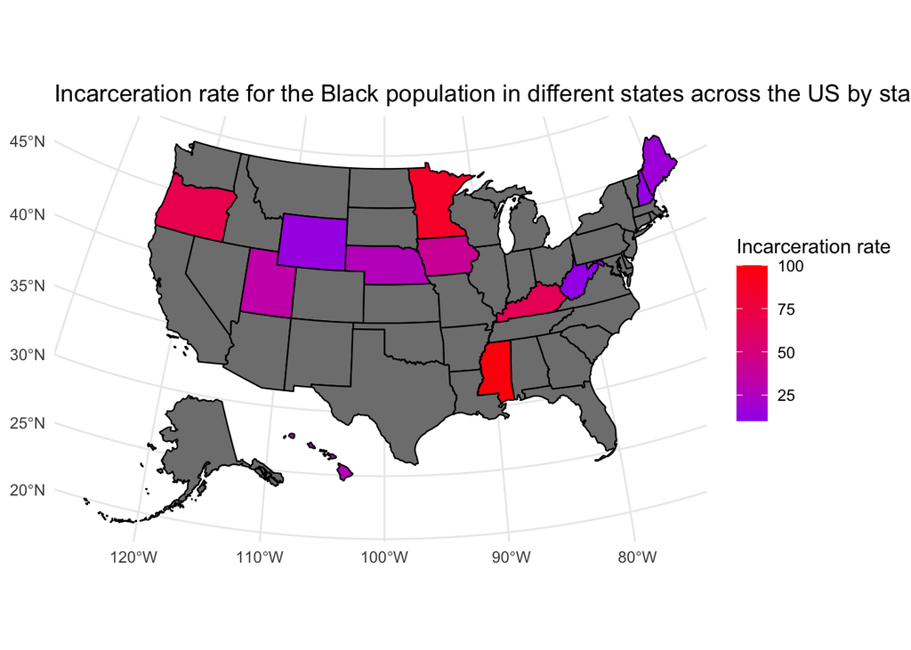